# Homework 1

Ashley Kang

9/18/2018

# Problem 1

## Creating a dataframe

The chunk below creates a dataframe containing a sample of size 10 from a random uniform[0,5] distributed variable, a logical vector indicating whether elements of the sample are greater than 2, a (length-10) character vector, and a (length-10) factor vector.

```r
set.seed(1)

prob1_df = tibble(unif_samp = runif(n = 10, min = 0, max = 5),
                  vec_logical = unif_samp > 2,
                  vec_char = c("This", "is", "my", "first", "homework",
                               "using", "R", "for", "data", "science"),
                  vec_factor = factor(c("less", "less", "greater", "greater",
                                        "less", "greater", "greater", "greater",
                                        "greater", "less"))
                  )
```

### Taking the mean of each variable

We will try to take the mean of each variable in the dataframe and see which variables return a mean value and which variables will not.

```r
mean(prob1_df$unif_samp)
mean(prob1_df$vec_logical)
mean(prob1_df$vec_char)
mean(prob1_df$vec_factor)
```

- Only numeric or logical variables will return a mean.
  - The mean for *unif_samp* is **2.7575694**.
  - The mean for *vec_logical* is **0.6**.
- Character and factor variables will not return a mean.
  - The mean for *vec_char* is **NA**.
  - The mean for *vec_factor* is **NA**.

### Explicitly converting variables

#### Converting into a numeric variable

The chunk below will explicitly convert logical, character, and factor variables into a numeric variable.

```r
as.numeric(prob1_df$vec_logical)
as.numeric(prob1_df$vec_char)
as.numeric(prob1_df$vec_factor)
```

The logical and factor variables were able to be converted into a numeric variable, but R was unable to turn a character variable into a numeric one (NAs introduced by coercion).

#### Converting a character variable

The chunk below will convert the character variable from character to factor to numeric

```r
as.factor(prob1_df$vec_char)
```

```
##  [1] This     is       my       first    homework using    R
##  [8] for      data     science
## Levels: data first for homework is my R science This using
```

```r
as.numeric(prob1_df$vec_char)
```

```
##  [1] NA NA NA NA NA NA NA NA NA NA
```

R was able to convert the character variable to a factor variable and created 10 levels. R was unable to convert the character variable to a numeric variable (NAs introduced by coercion).

#### Converting a factor variable

The chunk below will convert the factor variable from factor to character to numeric

```r
as.character(prob1_df$vec_factor)
```

```
##  [1] "less"    "less"    "greater" "greater" "less"    "greater" "greater"
##  [8] "greater" "greater" "less"
```

```r
as.numeric(prob1_df$vec_factor)
```

```
##  [1] 2 2 1 1 2 1 1 1 1 2
```

R was able to convert the factor variable to both a character and numeric variable. Now, there are 10 characters as opposed to 2 levels. There are only 2 numbers used - “1” to signify “greater” and “2” to signify “less”.

# Problem 2

## Creating a dataframe for variables x and y

The chunk below creates a dataframe comprised of x (a random sample of size 1000 from a standard Normal distribution), y (a random sample of size 1000 from a standard Normal distribution), a logical vector indicating whether the x + y > 0, a numeric vector created by coercing the above logical vector, and a factor vector created by coercing the above logical vector.

```r
set.seed(1)

prob2_df = tibble(x = rnorm(1000),
                  y = rnorm(1000),
                  xy_logical = x + y > 0,
                  num_coerc = as.numeric(xy_logical),
                  fac_coerc = as.factor(xy_logical)
                  )
```

The data set is comprise of **1000 rows** and **5 columns**. The mean for *x* is **-0.0116481** and the median for *x* is **-0.0353242**. The proportion of cases for which the logical vector is true is **0.49**.

## Scatterplot of x and y

The chunk below will create a scatterplot of y vs x.

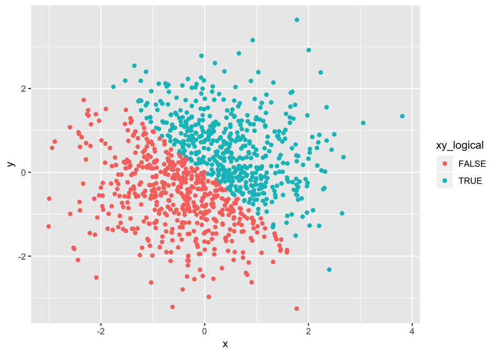

```r
ggplot(prob2_df, aes(x = x, y = y, color = xy_logical)) + geom_point()
```

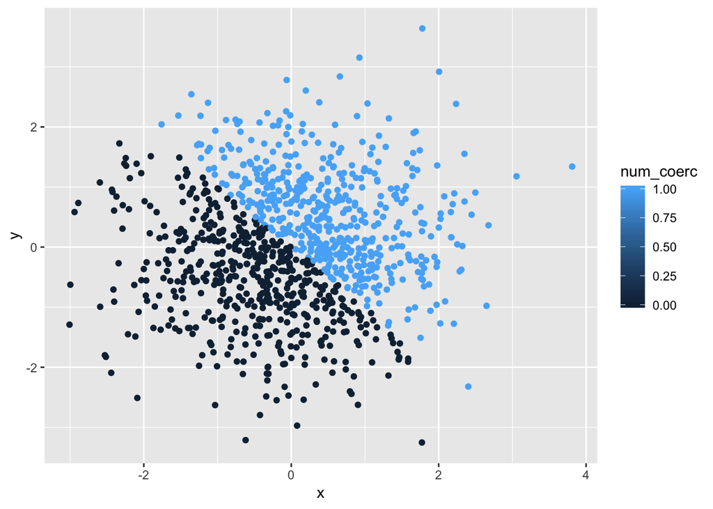

```r
ggplot(prob2_df, aes(x = x, y = y, color = num_coerc)) + geom_point()
```

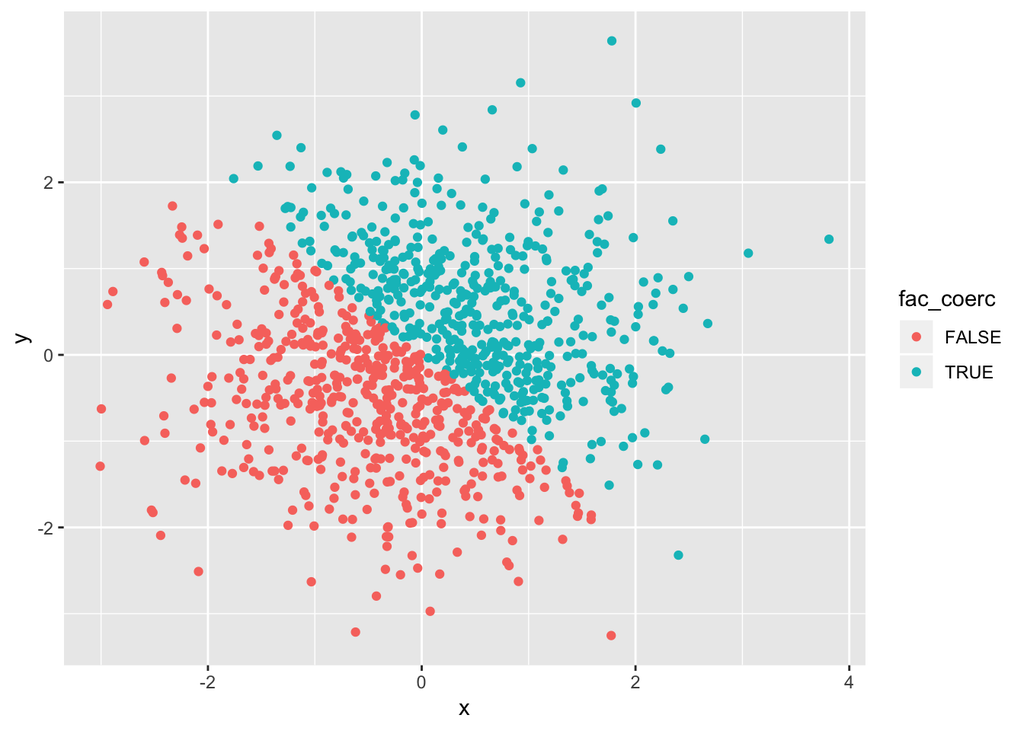

```r
ggplot(prob2_df, aes(x = x, y = y, color = fac_coerc)) + geom_point()
```